# Hands-on introduction to Qiskit

# Deutsch-Josza Algorithm

### Problem formulation

Consider a function $f: \{0,1\}^n \rightarrow \{0,1\}$ that maps an array of $n$ bits into either 0 or 1. We do not know the logic behind it. **We know that it is either constant or balanced**:

- **Constant**: its output is always 0 or always 1
- **Balanced**: outputs 0 for half the input value and 1 for the other half

For the case that $n=1$ we have $f: \{0,1\} \rightarrow \{0,1\}$ that maps a single bit into either 0 or 1. We are given a black box, an **oracle**, that takes as input a bit and outputs the unknown value.

[figure not shown]

To answer this question classically, we would always need two function invocations. We could do $f(0)$ and $f(1)$ and see if it is either constant or balanced.

Before transforming it into a quantum problem, we need our black box to be an oracle which allows for **reversible computation**, like so:

[figure not shown]

### Algorithm

Let us imagine the following procedure:

- We begin with two qubits, $|a \rangle$ in state $|0\rangle$ and $| b \rangle$ in state $|1\rangle$: $\; |01\rangle$.
- We apply a Hadamard to each qubit, the result is $\frac{1}{2}(|00\rangle - |01\rangle + |10\rangle - |11\rangle)$
- We now call our oracle, which maps $|ab\rangle$ or $|a\rangle |b\rangle$ (easier to interpret) into $|a\rangle |b \oplus f(a)\rangle$ the result is:

$$\frac{1}{2}( \; |0\rangle |0\oplus f(0)\rangle \;-\; |0\rangle |1\oplus f(0)\rangle \;+\; |1\rangle |0\oplus f(1)\rangle \;-\; |1 \rangle |1\oplus f(1)\rangle \;)$$

We can now use the following equivalence:

$$|0 \oplus a\rangle - |1 \oplus a\rangle = (-1)^a(|0\rangle - |1\rangle)$$

To replace above and get:

$$\frac{1}{2}[|0\rangle \,\otimes \, (-1)^{f(0)}(|0\rangle - |1\rangle)\; +\; |1\rangle \,\otimes \,(-1)^{f(1)}(|0\rangle - |1\rangle)]$$

This quantum state can be separated into the product state:

$$ [\frac{1}{\sqrt{2}} (-1)^{f(0)} | 0 \rangle + \frac{1}{\sqrt{2}} (-1)^{f(1)}| 1 \rangle] \; \otimes \; [\frac{1}{\sqrt{2}} | 0 \rangle - \frac{1}{\sqrt{2}} | 1 \rangle] $$

Our second qubit can now be ignored, and what remains is our first qubit, which contains both $f(0)$ and $f(1)$ - both images of $f$ with a single pass over the oracle. This can further be simplified as:

$$(-1)^{f(0)}(\frac{1}{\sqrt{2}} | 0 \rangle + \frac{1}{\sqrt{2}} (-1)^{f(0) \oplus f(1)} | 1 \rangle)$$

Lastly, we apply a Hadamard gate on our qubit and we arrive at:

$$(-1)^{f(0)} |f(0) \oplus f(1)\rangle$$

What is the meaning of this?

- if f is constant ($00$ or $11$) $\rightarrow$ output is $0$ (xor is 0)
- if f is balanced ($01$ or $10$) $\rightarrow$ output is $\pm 1$ (xor is 1)

Which, in fact, means that we can do a *single pass* over the oracle gate discover whether it is constant or balanced, an impossible feat in classical computing.

Generalizing for a function $f: \{0,1\}^n \rightarrow \{0,1\}$, a classical algorithm would need $2^{n-1}+1$ passes, while **a quantum function would still require 1 pass**.

[figure not shown]

**Quantum parallelism**: a quantum register has the ability to exist in a superposition of base states - each one may be thought of as a single argument to a function.

A function performed on the register in a superposition of states is thus performed on each of the components of the superposition, *while only being applied once*.

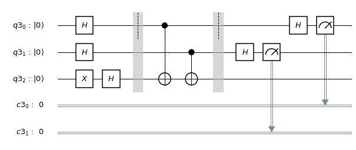

```python
# Create a quantum circuit with 3 qubits and 2 bits
qr = QuantumRegister(3)
cr = ClassicalRegister(2)
qc = QuantumCircuit(qr,cr)
# Flip ancilla qubit to |1>
qc.x(qr[2])
# Apply Hadamard gate to the whole register
qc.h(qr)
# Oracle
qc.barrier()
qc.cx(qr[0],qr[2])
qc.cx(qr[1],qr[2])
qc.barrier()
# Return qubits to the computational basis
qc.h(qr[0])
qc.h(qr[1])
# Measure
qc.measure(qr[0], cr[0])
qc.measure(qr[1], cr[1])
qc.draw(output='mpl')
```

```python
backend = BasicAer.get_backend("qasm_simulator")

shots = 1024
job_DJ_s = execute(qc, backend, shots=shots)

result_DJ_s = job_DJ_s.result()
counts_DJ_sim = result_DJ_s.get_counts(qc)
```

```python
backend = IBMQ.get_backend('ibmq_20_tokyo')

shots = 1024
job_DJ_r = execute(qc, backend, shots=shots)

jobID_DJ_r = job_DJ_r.job_id()

print('JOB ID: {}'.format(jobID_DJ_r))
```

```
JOB ID: 5c9e46bb54ca3d0062df21cb
```

```python
job_get=backend.retrieve_job(jobID_DJ_r)
result_DJ_r = job_get.result()
counts_DJ_run = result_DJ_r.get_counts(qc)
```

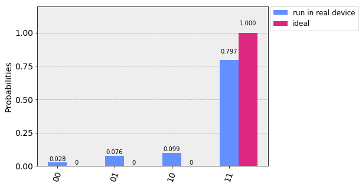

```python
plot_histogram([counts_DJ_run, counts_DJ_sim ], legend=[ 'run in real device', 'ideal'])
```

# Ignis

[figure not shown]

```python
from qiskit.ignis.mitigation.measurement import ( complete_meas_cal, CompleteMeasFitter, MeasurementFilter )
```

```python
# Generate the calibration circuits
qr = QuantumRegister(3)
meas_calibs, state_labels = complete_meas_cal(qubit_list=[0,1], qr=qr, circlabel='mcal')
```

```python
state_labels
```

```
['00', '01', '10', '11']
```

```python
job_ignis = execute(meas_calibs, backend=backend, shots=1000)
cal_results = job_ignis.result()
```

```python
# The calibration matrix without noise is the identity matrix
meas_fitter = CompleteMeasFitter(cal_results, state_labels, circlabel='mcal')
print(meas_fitter.cal_matrix)
```

```
[[0.967 0.122 0.055 0.015]
 [0.015 0.86  0.001 0.04 ]
 [0.016 0.003 0.934 0.153]
 [0.002 0.015 0.01  0.792]]
```

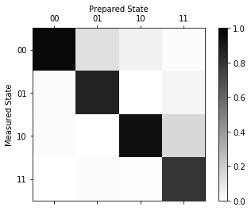

```python
# Plot the calibration matrix
meas_fitter.plot_calibration()
```

#### The fidelity of the target in the original and the adapted circuit

```python
# What is the measurement fidelity?
print("Average Measurement Fidelity: %f" % meas_fitter.readout_fidelity())

# What is the measurement fidelity of Q0? - target of the adapted circuit
print("Average Measurement Fidelity of Q0: %f" % meas_fitter.readout_fidelity(
    label_list = [['00','01'],['10','11']]))

# What is the measurement fidelity of Q1? - target of the original circuit
print("Average Measurement Fidelity of Q1: %f" % meas_fitter.readout_fidelity(
    label_list = [['00','10'],['01','11']]))
```

```
Average Measurement Fidelity: 0.888250
Average Measurement Fidelity of Q0: 0.963250
Average Measurement Fidelity of Q1: 0.919750
```

#### Applying Calibration

```python
# Get the filter object
meas_filter = meas_fitter.filter
```

```python
# Results of X3 with mitigation
mitigated_results = meas_filter.apply(result_DJ_r)
mitigated_counts = mitigated_results.get_counts(0)
```

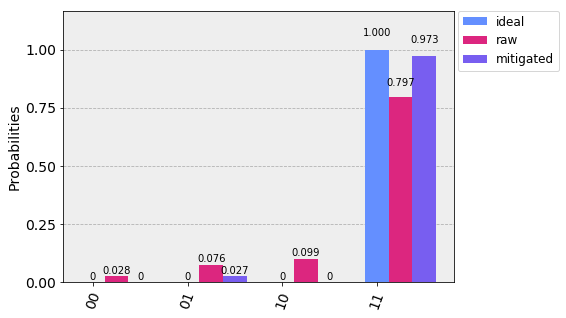

```python
plot_histogram([counts_DJ_sim, counts_DJ_run, mitigated_counts], legend=['ideal', 'raw', 'mitigated'])
```